# Simple Linear Regression: Practice Questions

2025

## Question 1

Write `R` code to generate data for a simple linear regression model in which the true slope is 0.5 and the true intercept is 2.

**Click here for the answer**

```r
library(data.table)
library(ggplot2)

x <- rnorm(100, 0, 1)
y <- 2 + 0.5 * x + rnorm(100, 0, 1)
d <- data.table(x, y)
fm <- lm(y ~ x, data = d)
ggplot(d, aes(x = x, y = y)) +
  geom_point() +
  geom_smooth(method = "lm", se = T) +
  labs(title = "Simple Linear Regression Model",
       x = "x",
       y = "y") +
  theme_minimal()
```

[output not shown]

## Question 2

What is a good guess for \(\beta_0\) and \(\beta_1\) in the following regression model?

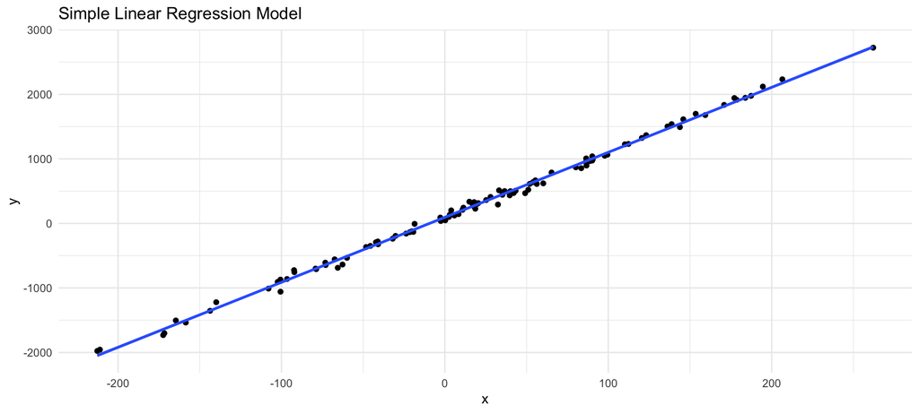

**Click here for the answer**

The idea is to simply read the values from the plot. The intercept is the value of \(y\) when \(x = 0\), and the slope is the change in \(y\) for a one unit increase in \(x\).

In this case, the true intercept is 100 and the true slope is 10.

## Question 3

Consider the following samples from \(X\) and \(Y\):

```r
x <- c(1.58, 1.23, 0.78, 0.45, 0.12, 0.98, 1.34, 1.56, 1.23, 0.89)
y <- c(0.45, 0.78, 1.23, 1.56, 1.89, 1.34, 1.12, 0.89, 0.56, 0.23)
```

What is the percentage of variance explained in \(y\) by \(x\) given a simple linear regression model?

**Click here for the answer**

```r
x <- c(1.58, 1.23, 0.78, 0.45, 0.12, 0.98, 1.34, 1.56, 1.23, 0.89)
y <- c(0.45, 0.78, 1.23, 1.56, 1.89, 1.34, 1.12, 0.89, 0.56, 0.23)
d <- data.table(x, y)
fm <- lm(y ~ x, data = d)
r2 <- summary(fm)$r.squared # extract percentage of variance explained
print(r2)
```

[output not shown]

## Question 4

Suppose that Pearson’s correlation coefficient between \(X\) and \(Y\) is 0.8. What is the percentage of variance explained in \(Y\) by \(X\)?

**Click here for the answer**

The percentage of variance explained is equal to the square of the correlation coefficient. Therefore, the percentage of variance explained is \(0.8^2 = 0.64\) or 64%.

## Question 5

Suppose that the coefficient of determination \(R^2\) is 0.64. What is the correlation coefficient between \(X\) and \(Y\)?

**Click here for the answer**

The correlation coefficient is equal to the square root of the coefficient of determination. Therefore, the correlation coefficient is \(\sqrt{0.64} = 0.8\).

## Question 6

Create three different sets of x and y data with increasing coefficient of determination \(R^2\) values.

**Click here for the answer**

```r
x1 <- rnorm(100, 0, 1)
y1 <- 2 + 0.5 * x1 + rnorm(100, 0, 1)
d1 <- data.table(x1, y1)
fm1 <- lm(y1 ~ x1, data = d1)

x2 <- rnorm(100, 0, 1)
y2 <- 2 + 0.8 * x2 + rnorm(100, 0, 0.5)
d2 <- data.table(x2, y2)
fm2 <- lm(y2 ~ x2, data = d2)

x3 <- rnorm(100, 0, 1)
y3 <- 2 + 0.9 * x3 + rnorm(100, 0, 0.1)
d3 <- data.table(x3, y3)
fm3 <- lm(y3 ~ x3, data = d3)

print(summary(fm1)$r.squared)
print(summary(fm2)$r.squared)
print(summary(fm3)$r.squared)
```

[output not shown]